# Pantaleo - Exploratory Analysis - TFH095

Valentin Voillet

# Contents

*File creation: July, 05th 2017*  
*Update: July, 05th 2017*

# 1 Data Loading & Description

Briefly, paired PBMCs (Peripheral blood mononuclear cells) and LN (Lymph Node) from patients were stained and sorted for Tfh (T Follicular Helper) and Live cells. There are three HIV+ CP off treatment and three HIV- patients.

Per patient, per sample, two Seq-Well arrays were processed. *NB: each patient has the following processed array conditions: LN TFH, LN Live, PBMC TFH, & PBMC Live.*

Here - we have two arrays from one HIV- CP patient - **TFH095**. No Tfh arrrays for this patient yet.

**Obj: Re-perform the analysis - Look at the data for patient TFH095.**

# 2 Live Cells

## 2.1 Raw Count

Let’s look at the distribution of UMIs and nb. of detected genes in both LN and PBMC samples for Live Cells.

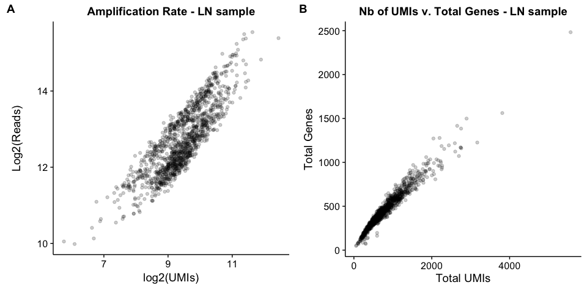

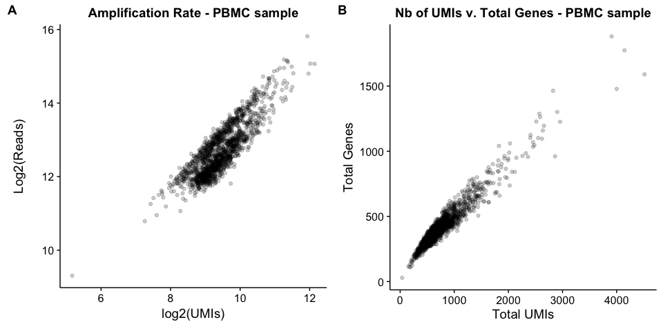

For LN sample, we have an amplification biais - that’s why we use UMIs - correlation between UMIs and reads. It seems to exhibit a quite proportional capture efficient here, whereas current platforms (DropSeq, etc.) usually exhibit low and highly variable capture efficiency.

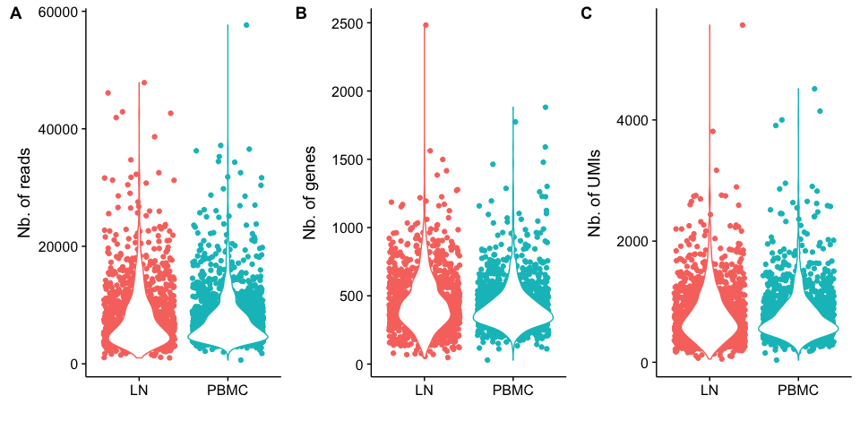

Really close nb. of reads, UMIs and detected genes are observed in both LN and PBMC samples from Live Cells.

## 2.2 QC and Filtering

The next step is to perform quality control and filtering (remove cells with few reads/UMIs or genes, etc.). The threshold that Sam used was **750 UMIs** and **400 genes** (see *Slides for Pantaleo 053017.ppt* file). So, let’s use the same here, and also remove genes with less than one UMI count.

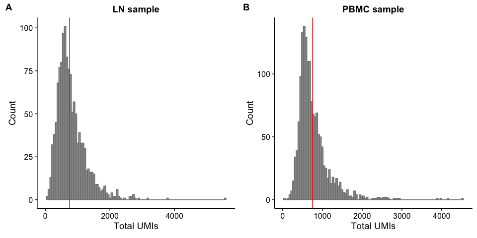

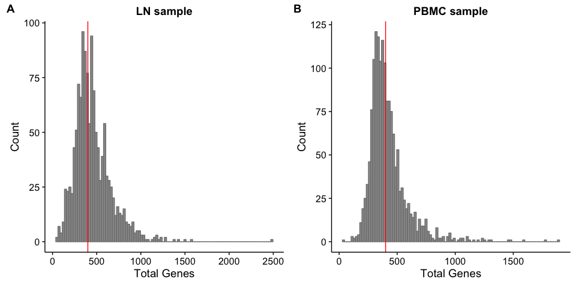

As highlighted by Sam, the runs are probably a bit under sequenced.

```r
###--- Filtering datasets and merging
#- LN
identical(colnames(LiveCells_LN_UMI), rownames(LiveCells_LN_UMI_summary)) # TRUE
LiveCells_LN_UMI_filtered <- LiveCells_LN_UMI[, which(LiveCells_LN_UMI_summary$NUM_GENES >= 400 & LiveCells_LN_UMI_summary$NUM_TRANSCRIPTS >= 750)] # 558 cells
LiveCells_LN_UMI_filtered <- LiveCells_LN_UMI_filtered[which(apply(LiveCells_LN_UMI_filtered, 1, sum) != 0), ] # 15,466 genes and 558 cells
#- PBMC
identical(colnames(LiveCells_PBMC_UMI), rownames(LiveCells_PBMC_UMI_summary)) # TRUE
LiveCells_PBMC_UMI_filtered <- LiveCells_PBMC_UMI[, which(LiveCells_PBMC_UMI_summary$NUM_GENES >= 400 & LiveCells_PBMC_UMI_summary$NUM_TRANSCRIPTS >= 750)] # 564 cells
LiveCells_PBMC_UMI_filtered <- LiveCells_PBMC_UMI_filtered[which(apply(LiveCells_PBMC_UMI_filtered, 1, sum) != 0), ] # 14,740 genes and 564 cells
#- Merging
LiveCells_UMI <- rbind.fill(as.data.frame(t(LiveCells_LN_UMI_filtered)), as.data.frame(t(LiveCells_PBMC_UMI_filtered)))
rownames(LiveCells_UMI) <- c(paste(colnames(LiveCells_LN_UMI_filtered), 'LN', sep = '_'), paste(colnames(LiveCells_PBMC_UMI_filtered), 'PBMC', sep = '_'))
dim(LiveCells_UMI) # 1,122 cells and 17,757 genes
length(unique(c(rownames(LiveCells_LN_UMI_filtered), rownames(LiveCells_PBMC_UMI_filtered)))) # 17,757 genes
LiveCells_UMI[is.na(LiveCells_UMI)] <- 0 # NAs - replace NA by 0
LiveCells_UMI <- as.data.frame(t(LiveCells_UMI))
```

After filtering, we have:

- **15,466 genes** and **558 cells** - LN sample
- **14,740 genes** and **564 cells** - PBMC sample

After merging those two datasets together, we have:

- **1,122 cells** and **17,757 genes**

## 2.3 Normalization

As in Gierahn et al. (2017), for each cell, we perform library-size normalization. UMI-collapsed gene expression values for each cell barcode were scaled by the total number of transcripts and multiplied by 10,000. Scaled expression data were then natural-log transformed before analysis using Seurat.  
*NB: Scaling and log2-transformation actually done with Seurat.*

```r
###--- Normalization
#- Seurat object - log2-transformation & library-size normalization - done on Rhino - why? issue with R 3.4.0
seuratObj <- new('seurat', raw.data = LiveCells_UMI)
seuratObj <- Setup(seuratObj, min.cells = 0, min.genes = 0, project = 'Pantaleo', total.expr = 10000) # no need to filter - already done
#- Output
saveRDS(seuratObj, file = 'Output_070517/LiveCells_TFH095.rds')
seuratObj_LiveCells_global <- readRDS('Output_070517/LiveCells_TFH095.rds') # 1,122 cells & 17,757 genes
```

## 2.4 Seurat Analysis

Seurat analysis using the normalized dataset. It includes the removing of unwanted sources of variation, PCA, clustering and tSNE. All analyses are done as in Gierahn et al. (2017).

The single cell dataset likely contains *uninteresting* sources of variation. This could include not only technical noise, but batch effects, or even biological sources of variation (cell cycle stage). As suggested in Buettner et al. (2015), regressing these signals out of the analysis can improve downstream dimensionality reduction and clustering. Seurat implements a basic version of this by constructing linear models to predict gene expression based on user-defined variables. Seurat stores the z-scored residuals of these models in the scale.data slot, and they are used for dimensionality reduction and clustering. We typically regress out cell-cell variation in gene expression driven by batch (if applicable), cell alignment rate (as provided by Drop-seq tools for Drop-seq data), the number of detected molecules and mitochondrial gene expression. For cycling cells, we can also learn a cell-cycle score (as in Macosko et al. (2015)) and Regress this out as well - from Gierahn et al. (2017).  
Here, we simply regress on the number of UMIs per cell as well as the percentage mitochondrial gene content.

```r
###--- Regress out unwanted sources of variation
mito.genes <- grep("^MT-", rownames(seuratObj_LiveCells_global@data), value = TRUE)
percent.mito <- colSums(as.matrix(expm1(seuratObj_LiveCells_global@data[mito.genes, ]))) / colSums(as.matrix(expm1(seuratObj_LiveCells_global@data)))
seuratObj_LiveCells_global <- AddMetaData(seuratObj_LiveCells_global, percent.mito, 'percent.mito')
GenePlot(seuratObj_LiveCells_global, 'nUMI', 'percent.mito')
GenePlot(seuratObj_LiveCells_global, 'nUMI', 'nGene') # 0.94
#- remove unwanted sources of variation
seuratObj_LiveCells_global <- RegressOut(seuratObj_LiveCells_global, latent.vars = c('nUMI', 'percent.mito')) # remove effect of CDR (high correlation between nGene and nUMI - 0.94) and mitochondrial
```

After, Seurat calculates highly variable genes and focuses on these for downstream analysis.

```r
###--- Detection of variable genes across the single cells
seuratObj_LiveCells_global <- MeanVarPlot(seuratObj_LiveCells_global, fxn.x = expMean, fxn.y = logVarDivMean, x.low.cutoff = 0.25, x.high.cutoff = 3, y.cutoff = 0.5, do.contour = FALSE)
length(seuratObj_LiveCells_global@var.genes) # 887 highly variable genes
```

We identify 887 variable genes with log-mean expression values greater than 0.25 and dispersion (variance/mean) greater than 0.5.

```r
###--- PCA
#- PCA performed on the scaled data and using only highly variable genes
seuratObj_LiveCells_global <- PCA(seuratObj_LiveCells_global, pc.genes = seuratObj_LiveCells_global@var.genes)
seuratObj_LiveCells_global <- ProjectPCA(seuratObj_LiveCells_global)
```

We can identify markers that are strongly correlated with cellular heterogeneity - see below.

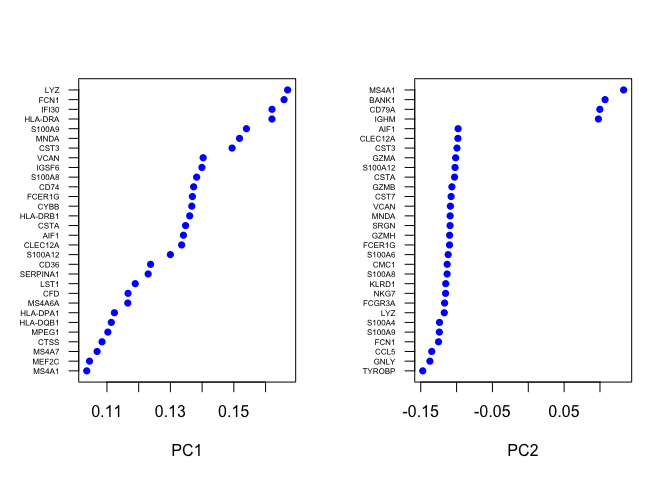

We performed 1,000 iterations of the t-SNE algorithm using a perplexity value of 40 and the first top 5 principal components. Those first top 5 PCs were chosen according to the standard deviation - see below.

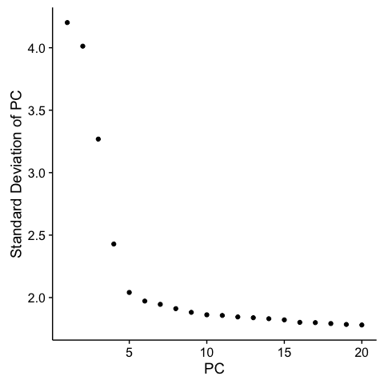

```r
###--- tSNE
seuratObj_LiveCells_global <- RunTSNE(seuratObj_LiveCells_global, dims.use = 1:5, perplexity = 40, do.fast = TRUE)
```

Let’s look at the tSNE plots now - perplexity of 40 and 1,000 iterations of the Barnes-Hut implementation.

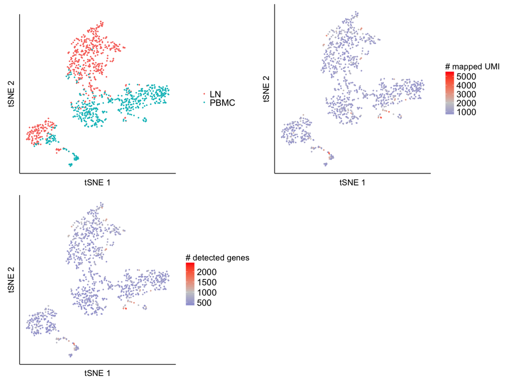

Big separation between PBMC and LN samples. Is it a technical effect? We’ll see once we combine all HIV- patients together.

When we look at the expression of some cell markers - see below.

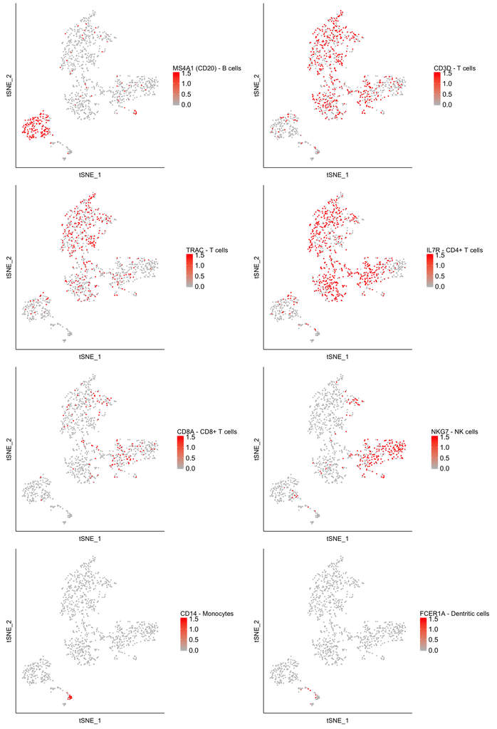

We see B cells, T cells, NK cells and APCs (CD14+ Monocytes / dentritic cells). However, unlike Sam, I think that we do have B cells in TFH095 from PBMC sample (less than from LN sample for sure but they are here). I double-checked, normally I haven’t made any mistakes. I might not use the same threshold.

Let’s look at the clustering proposed by Seurat (Graph-based method).  
Cell classification and clustering were performed using a graph-based clustering method implemented in Seurat (FindClusters R function - share nearest neighbor (SNN) modularity optimization based clustering algorithm). Briefly, it calculates k-nearest neighbors and constructs the SNN graph. Then, it optimises the modularity function to determine the best clusters. Six distinct clusters of cells were identified using the top 5 PCs with a neighbourhood size of 40 and resolution of 0.80.

```r
###--- Clustering
seuratObj_LiveCells_global <- FindClusters(seuratObj_LiveCells_global, pc.use = 1:5, resolution = 0.80, print.output = 0, k.param = 40, save.SNN = FALSE)
```

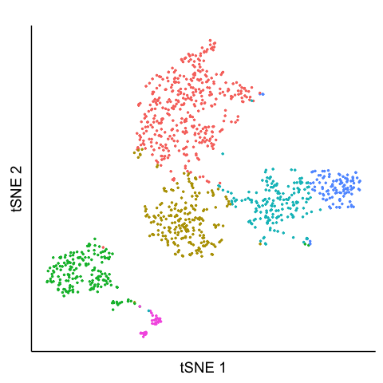

We have 6 clusters: B cells, NK cells, CD8 cytotoxic T cells, T cells (LN) and T cells (PBMC).

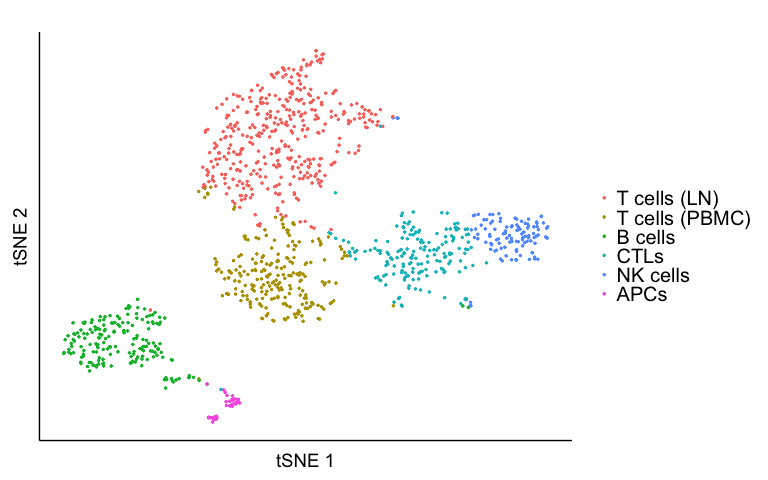